# Forest Plots with Built-In Tables

Creating forest plots with coefficient tables in ggplot2 with cowplot

I’ve seen this kind of figure poking around, but I didn’t really think about them until the other day I was asked about how to make one in R. Here I will walk through making one of these plots using the `ggplot2` and `cowplot` packages.

english

R

plots

tutorial

Author

Affiliation

[Brynjólfur Gauti Guðrúnar Jónsson](https://twitter.com/bgautijonsson)

[Tölfræði, Raunvísindadeild Háskóla Íslands](https://www.hi.is/tolfraedi_0)

Published

June 28, 2022

I’ve seen this kind of figure poking around, but I didn’t really think about them until the other day I was asked about how to make one in R. Here I will walk through making one of these plots using the `ggplot2` and `cowplot` packages.

To start with I have some fake data, `d`.

```r
d |>
    kable(format = "html") |>
    kable_styling(full_width = F)
```

| name | mean | lower | upper |
| --- | --- | --- | --- |
| Covfefe | 1.1989430 | 1.0707825 | 1.358700 |
| Coffee | 1.8509518 | 1.5589701 | 2.227752 |
| Variable | 1.2181512 | 1.0834045 | 1.411683 |
| Covariate | 1.1970336 | 1.0699671 | 1.342737 |
| Predictor | 0.9085823 | 0.8049225 | 1.000000 |
| Smoking | 0.8770238 | 0.7447709 | 1.000000 |
| Age | 0.9344551 | 0.8305984 | 1.000000 |
| Uranium | 0.9177338 | 0.8021060 | 1.000000 |
| Stuff | 1.0760010 | 1.0000000 | 1.216474 |
| Thing | 0.9143605 | 0.7753231 | 1.000000 |
| Koffing | 1.0686924 | 1.0000000 | 1.178642 |
| Coughing | 1.0648236 | 1.0000000 | 1.194998 |
| Polvo | 0.9227277 | 0.8097846 | 1.000000 |

### The Forest Plot

The forest plot itself is not hard to do. Notice how I create this striped pattern with `geom_vline(aes(xintercept = name), col = "grey95", size = 5)`. I’ll do the same thing to the table part of the figure later.

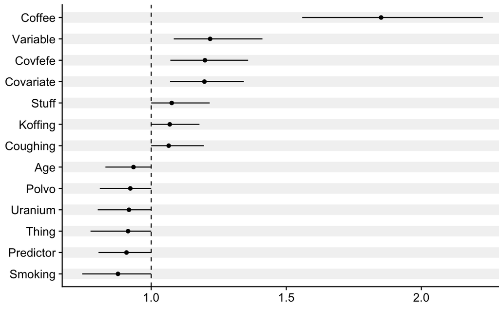

```r
p1 <- d |>
    mutate(name = fct_reorder(name, mean)) |>
    ggplot(aes(x = name, y = mean,
                  ymin = lower, ymax = upper)) +
    geom_vline(aes(xintercept = name), col = "grey95", size = 5) +
    geom_hline(yintercept = 1, lty = 2) +
    geom_point() +
    geom_linerange() +
    coord_flip() +
    labs(x = NULL, y = NULL) +
    theme(plot.margin = margin(t = 5, r = -4, b = 5, l = 5))

p1
```

### The Table

To make the table look nice I convert the numbers to text and clean them up so that the text is justified nicely when plotting it. I did some manual tuning of the margins to make the plot and table line up nicely.

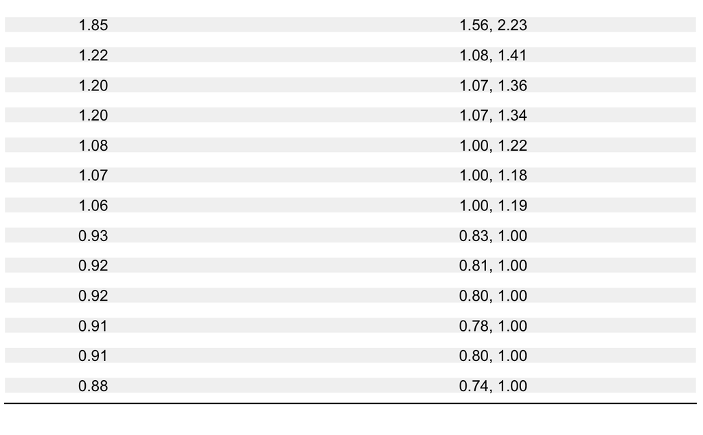

```r
p2 <- d |>
    mutate(name = fct_reorder(name, mean),
           mean = round(mean, 2),
           mean = str_pad(mean, width = 4, side = "right", pad = "0"),
           lower = round(lower, 2),
           lower = as.character(lower),
           lower = ifelse(lower == "1", "1.00", lower),
           lower = str_pad(lower, width = 4, side = "right", pad = "0"),
           upper = round(upper, 2),
           upper = as.character(upper),
           upper = ifelse(upper == "1", "1.00", upper),
           upper = str_pad(upper, width = 4, side = "right", pad = "0"),
           ci = str_c(lower, ", ", upper)) |>
    ggplot(aes(x = name)) +
    geom_vline(aes(xintercept = name), col = "grey95", size = 5) +
    geom_text(aes(label = mean, y = 1)) +
    geom_text(aes(label = ci, y = 1.07)) +
    coord_flip(ylim = c(0.99, 1.1)) +
    theme(axis.title = element_blank(),
          axis.text = element_blank(),
          axis.ticks = element_blank(),
          axis.line.y = element_blank(),
          panel.border = element_blank(),
          panel.grid = element_blank(),
          plot.background = element_blank(),
          plot.margin = margin(t = 5, r = 5, b = 19.3, l = 0))

p2
```

#### The finished bottom row

Now we have alligned the plot and table. If you zoom in you might see that they don’t line up perfectly. I am not liable for any bodily harm caused by this.

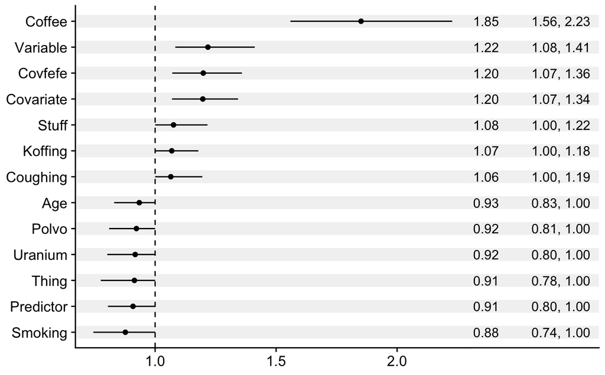

```r
bottom_row <- plot_grid(p1, p2, nrow = 1, rel_widths = c(1, 0.3))

bottom_row
```

### The headers

I admit that this is a pretty handwavy manual way to make the header fit, and there is probably a nice way to automatically fit this using the coordinate system.

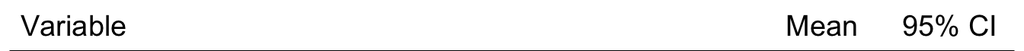

```r
top_row <- ggplot(data = tibble()) +
    geom_text(aes(y = 1, x = 0.02, label = "Variable"), size = 5) +
    geom_text(aes(y = 1, x = 0.84, label = "Mean"), size = 5) +
    geom_text(aes(y = 1, x = 0.98, label = "95% CI"), size = 5) +
    coord_cartesian(xlim = c(0, 1)) +
    theme_void() +
    theme(plot.margin = margin(t = 0, r = 5, b = 0, l = 5),
          axis.line.x.bottom = element_line())


top_row
```

### Putting it all together

And so we come to the finished plot. If we wrangle the `rel_heights` setting a little bit we can get a pretty nice looking forest plot and table hybrid.

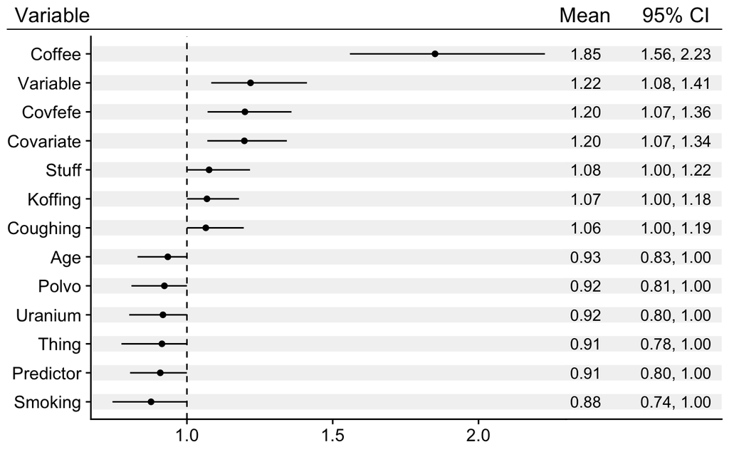

```r
plot_grid(top_row, bottom_row, ncol = 1, rel_heights = c(0.07, 1))
```

This was actually less of an inconvenience than I thought. The mixture of `ggplot2` and `cowplot` made this a pretty easy task.